Si te gusta **Skforecast** , ayúdanos dándonos una estrella en [GitHub](https://github.com/JoaquinAmatRodrigo/skforecast/)! ⭐️

# Predicción (*forecasting*) de la demanda energética con machine learning

**Joaquín Amat Rodrigo, Javier Escobar Ortiz**

*Febrero, 2021 (última actualización Abril 2024)*

Más sobre ciencia de datos: [**cienciadedatos.net**](https://cienciadedatos.net)

- [Forecasting series temporales con Python y Scikit Learn](https://www.cienciadedatos.net/documentos/py27-forecasting-series-temporales-python-scikitlearn.html)
- [Forecasting series temporales con gradient boosting: scikit-learn, XGBoost, LightGBM y CatBoost](https://www.cienciadedatos.net/documentos/py39-forecasting-series-temporales-con-skforecast-xgboost-lightgbm-catboost.html)
- [Global Forecasting: Multi-series forecasting](https://www.cienciadedatos.net/documentos/py44-multi-series-forecasting-skforecast-espa%C3%B1ol.html)
- [Predicción (forecasting) de visitas a página web con machine learning](https://www.cienciadedatos.net/documentos/py37-forecasting-visitas-web-machine-learning.html)
- [Predicción del precio de Bitcoin con Python](https://www.cienciadedatos.net/documentos/py41-forecasting-criptomoneda-bitcoin-machine-learning-python.html)
- [Intervalos de predicción en modelos de forecasting](https://www.cienciadedatos.net/documentos/py42-forecasting-probabilistico.html)
- [Predicción de demanda intermitente](https://www.cienciadedatos.net/documentos/py48-forecasting-demanda-intermitente.html)

[figure not shown]

## Introducción

La predicción de la demanda energética desempeña un papel fundamental en la gestión y planificación de los recursos necesarios para la generación, distribución y utilización de la energía. Predecir la demanda de energía es una tarea compleja en la que influyen factores como los patrones meteorológicos, las condiciones económicas y el comportamiento de la sociedad. Este documento muestra cómo utilizar modelos de machine learning para predecir la demanda de energía.

**Series temporales y forecasting**

Una serie temporal (*time series*) es una sucesión de datos ordenados cronológicamente, espaciados a intervalos iguales o desiguales. El proceso de *forecasting* consiste en predecir el valor futuro de una serie temporal, bien modelando la serie únicamente en función de su comportamiento pasado (autorregresivo) o empleando otras variables externas.

[figure not shown]

Cuando se trabaja con series temporales, raramente se quiere predecir solo el siguiente elemento de la serie ($t_{+1}$), sino todo un horizonte futuro ($t_{+1}$), ..., ($t_{+n}$)) o un punto alejado en el tiempo ($t_{+n}$). Existen varias estrategias que permiten generar este tipo de predicciones, la librería **skforecast** recoge las siguientes para [series temporales univariantes](https://skforecast.org/latest/introduction-forecasting/introduction-forecasting.html):

- [**Forecasting multi-step recursivo**](https://skforecast.org/latest/introduction-forecasting/introduction-forecasting.html#recursive-multi-step-forecasting): este método consiste en utilizar propias predicciones del modelo como valores de entrada para predecir el siguiente valor. Por ejemplo, para predecir los 5 valores siguientes de una serie temporal, se entrena un modelo para predecir el siguiente valor ($t_{+1}$), y se utiliza este valor para predecir el siguiente ($t_{+2}$), y así sucesivamente. Todo este proceso se automatiza con las clases `ForecasterAutoreg` y `ForecasterAutoregCustom`.
- [**Forecasting multi-step directo**](https://skforecast.org/latest/introduction-forecasting/introduction-forecasting.html#direct-multi-step-forecasting): este método consiste en entrenar un modelo diferente para cada valor futuro (*step*) del horizonte de predicción. Por ejemplo, para predecir los 5 siguientes valores de una serie temporal, se entrenan 5 modelos diferentes, uno para cada *step*. De este modo, las predicciones son independientes entre sí. Todo este proceso se automatiza en la clase `ForecasterAutoregDirect`.

**✎ Nota**

Otros dos ejemplos de cómo utilizar machine learning (*gradient boosting*) para forecasting de series temporales son:

- [Forecasting series temporales con gradient boosting: scikit-learn, XGBoost, LightGBM y CatBoost](https://cienciadedatos.net/documentos/py39-forecasting-series-temporales-con-skforecast-xgboost-lightgbm-catboost.html).
- [Modelos globales para forecasting: Análisis comparativo de modelos de forecasting individuales y multi-series](https://cienciadedatos.net/documentos/py53-modelos-globales-forecasting.html).

## Librerías

Las librerías utilizadas en este documento son:

```python
# Tratamiento de datos
# ==============================================================================
import numpy as np
import pandas as pd
from astral.sun import sun
from astral import LocationInfo
from skforecast.datasets import fetch_dataset

# Gráficos
# ==============================================================================
import matplotlib.pyplot as plt
from statsmodels.graphics.tsaplots import plot_acf
from statsmodels.graphics.tsaplots import plot_pacf
from skforecast.plot import plot_residuals
import plotly.graph_objects as go
import plotly.io as pio
import plotly.offline as poff
pio.templates.default = "seaborn"
poff.init_notebook_mode(connected=True)
plt.style.use('seaborn-v0_8-darkgrid')
plt.rcParams.update({'font.size':8})

# Modelado y Forecasting
# ==============================================================================
import skforecast
import lightgbm
import sklearn
from lightgbm import LGBMRegressor
from sklearn.preprocessing import PolynomialFeatures
from sklearn.feature_selection import RFECV
from skforecast.ForecasterBaseline import ForecasterEquivalentDate
from skforecast.ForecasterAutoreg import ForecasterAutoreg
from skforecast.ForecasterAutoregDirect import ForecasterAutoregDirect
from skforecast.model_selection import bayesian_search_forecaster
from skforecast.model_selection import backtesting_forecaster
from skforecast.model_selection import select_features
import shap
shap.initjs()

# Configuración warnings
# ==============================================================================
import warnings
warnings.filterwarnings('once')

print(f"Versión skforecast: {skforecast.__version__}")
print(f"Versión lightgbm: {lightgbm.__version__}")
print(f"Versión scikit-learn: {sklearn.__version__}")
```

```
Versión skforecast: 0.12.0
Versión lightgbm: 4.3.0
Versión scikit-learn: 1.3.2
```

## Datos

Se dispone de una serie temporal de la demanda de electricidad (MW) para el estado de Victoria (Australia) desde 2011-12-31 hasta 2014-12-31. Los datos empleados en este documento se han obtenido del paquete de **R** tsibbledata. El set de datos contiene 5 columnas y 52608 registros completos. La información de cada columna es:

- Time: fecha y hora del registro.
- Date: fecha del registro
- Demand: demanda de electricidad (MW).
- Temperature: temperatura en Melbourne, capital de Victoria.
- Holiday: indicador si el día es festivo (vacaciones).

```python
# Descarga de datos
# ==============================================================================
datos = fetch_dataset(name='vic_electricity', raw=True)
datos.info()
```

```
vic_electricity
---------------
Half-hourly electricity demand for Victoria, Australia
O'Hara-Wild M, Hyndman R, Wang E, Godahewa R (2022).tsibbledata: Diverse
Datasets for 'tsibble'. https://tsibbledata.tidyverts.org/,
https://github.com/tidyverts/tsibbledata/.
https://tsibbledata.tidyverts.org/reference/vic_elec.html
Shape of the dataset: (52608, 5)
<class 'pandas.core.frame.DataFrame'>
RangeIndex: 52608 entries, 0 to 52607
Data columns (total 5 columns):
 #   Column       Non-Null Count  Dtype
---  ------       --------------  -----
 0   Time         52608 non-null  object
 1   Demand       52608 non-null  float64
 2   Temperature  52608 non-null  float64
 3   Date         52608 non-null  object
 4   Holiday      52608 non-null  bool
dtypes: bool(1), float64(2), object(2)
memory usage: 1.7+ MB
```

La columna `Time` está almacenada como `string`. Para convertirla en `datetime`, se emplea la función `pd.to_datetime()`. Una vez en formato `datetime`, y para hacer uso de las funcionalidades de **pandas**, se establece como índice. Además, dado que los datos se han registrado cada 30 minutos, se indica la frecuencia `'30min'`.

```python
# Conversión del formato fecha
# ==============================================================================
datos['Time'] = pd.to_datetime(datos['Time'], format='%Y-%m-%dT%H:%M:%SZ')
datos = datos.set_index('Time')
datos = datos.asfreq('30min')
datos = datos.sort_index()
datos.head(2)
```

| Time | Demand | Temperature | Date | Holiday |
| --- | --- | --- | --- | --- |
| 2011-12-31 13:00:00 | 4382.825174 | 21.40 | 2012-01-01 | True |
| 2011-12-31 13:30:00 | 4263.365526 | 21.05 | 2012-01-01 | True |

Uno de los primeros análisis que hay que realizar al trabajar con series temporales es verificar si la serie está completa.

```python
# Verificar que un índice temporal está completo
# ==============================================================================
(datos.index == pd.date_range(start=datos.index.min(),
                              end=datos.index.max(),
                              freq=datos.index.freq)).all()

print(f"Filas con valores ausentes: {datos.isnull().any(axis=1).mean()}")
```

```
Filas con valores ausentes: 0.0
```

```python
# Completar huecos en un índice temporal
# ==============================================================================
# datos.asfreq(freq='30min', fill_value=np.nan)
```

Aunque los datos se encuentran en intervalos de 30 minutos, el objetivo es crear un modelo capaz de predecir la demanda eléctrica a nivel horario, por lo que se tienen que agregar los datos. Este tipo de transformación es muy sencillas si se combina el índice `DatetimeIndex` de pandas y su método `resample()`.

Es muy importante utilizar correctamente los argumentos `closed='left'` y `label='right'` para no introducir en el entrenamiento información a futuro (*leakage*)). Supóngase que se dispone de valores para las 10:10, 10:30, 10:45, 11:00, 11:12 y 11:30. Si se quiere obtener el promedio horario, el valor asignado a las 11:00 debe calcularse utilizando los valores de las 10:10, 10:30 y 10:45; y el de las 12:00, con el valor de las 11:00, 11:12 y 11:30.

[figure not shown]

*Diagrama de agregado de datos temporales sin incluir información de futuro.*

Para el valor promedio de las 11:00 no se incluye el valor puntual de las 11:00 por que, en la realidad, en ese momento exacto no se dispone todavía del valor.

```python
# Agregado en intervalos de 1H
# ==============================================================================
# Se elimina la columna Date para que no genere error al agregar. La columna Holiday
# no genera error ya que es booleana y se trata como 0-1.
datos = datos.drop(columns='Date')
datos = datos.resample(rule='H', closed='left', label ='right').mean()
datos
```

| Time | Demand | Temperature | Holiday |
| --- | --- | --- | --- |
| 2011-12-31 14:00:00 | 4323.095350 | 21.225 | 1.0 |
| 2011-12-31 15:00:00 | 3963.264688 | 20.625 | 1.0 |
| 2011-12-31 16:00:00 | 3950.913495 | 20.325 | 1.0 |
| 2011-12-31 17:00:00 | 3627.860675 | 19.850 | 1.0 |
| 2011-12-31 18:00:00 | 3396.251676 | 19.025 | 1.0 |
| ... | ... | ... | ... |
| 2014-12-31 09:00:00 | 4069.625550 | 21.600 | 0.0 |
| 2014-12-31 10:00:00 | 3909.230704 | 20.300 | 0.0 |
| 2014-12-31 11:00:00 | 3900.600901 | 19.650 | 0.0 |
| 2014-12-31 12:00:00 | 3758.236494 | 18.100 | 0.0 |
| 2014-12-31 13:00:00 | 3785.650720 | 17.200 | 0.0 |

26304 rows × 3 columns

```python
# Separación datos train-val-test
# ==============================================================================
datos = datos.loc['2012-01-01 00:00:00': '2014-12-30 23:00:00'].copy()
fin_train = '2013-12-31 23:59:00'
fin_validacion = '2014-11-30 23:59:00'
datos_train = datos.loc[: fin_train, :].copy()
datos_val   = datos.loc[fin_train:fin_validacion, :].copy()
datos_test  = datos.loc[fin_validacion:, :].copy()

print(f"Fechas train      : {datos_train.index.min()} --- {datos_train.index.max()}  (n={len(datos_train)})")
print(f"Fechas validacion : {datos_val.index.min()} --- {datos_val.index.max()}  (n={len(datos_val)})")
print(f"Fechas test       : {datos_test.index.min()} --- {datos_test.index.max()}  (n={len(datos_test)})")
```

```
Fechas train      : 2012-01-01 00:00:00 --- 2013-12-31 23:00:00  (n=17544)
Fechas validacion : 2014-01-01 00:00:00 --- 2014-11-30 23:00:00  (n=8016)
Fechas test       : 2014-12-01 00:00:00 --- 2014-12-30 23:00:00  (n=720)
```

## Exploración gráfica

La exploración gráfica de series temporales es una forma eficaz de identificar tendencias, patrones y estacionalidad. Esto, a su vez, ayuda a orientar la selección del modelo de forecasting más adecuado.

### Gráfico de la serie temporal

**Serie temporal completa**

```python
# Gráfico interactivo de la serie temporal
# ==============================================================================
fig = go.Figure()
fig.add_trace(go.Scatter(x=datos_train.index, y=datos_train['Demand'], mode='lines', name='Train'))
fig.add_trace(go.Scatter(x=datos_val.index, y=datos_val['Demand'], mode='lines', name='Validation'))
fig.add_trace(go.Scatter(x=datos_test.index, y=datos_test['Demand'], mode='lines', name='Test'))
fig.update_layout(
    title  = 'Demanda eléctrica horaria',
    xaxis_title="Fecha",
    yaxis_title="Demanda (MWh)",
    legend_title="Partición:",
    width=850,
    height=400,
    margin=dict(l=20, r=20, t=35, b=20),
    legend=dict(
        orientation="h",
        yanchor="top",
        y=1,
        xanchor="left",
        x=0.001
    )
)
#fig.update_xaxes(rangeslider_visible=True)
fig.show()
```

[interactive chart not shown]

El gráfico anterior muestra que la demanda eléctrica tiene estacionalidad anual. Se observa un incremento centrado en el mes de Julio y picos de demanda muy acentuados entre enero y marzo.

**Sección de la serie temporal**

Debido a la varianza de la serie temporal, no es posible apreciar con un solo gráfico el posible patrón intradiario.

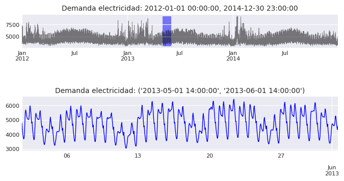

```python
# Gráfico serie temporal con zoom
# ==============================================================================
zoom = ('2013-05-01 14:00:00','2013-06-01 14:00:00')
fig = plt.figure(figsize=(8, 4))
grid = plt.GridSpec(nrows=8, ncols=1, hspace=0.6, wspace=0)
main_ax = fig.add_subplot(grid[1:3, :])
zoom_ax = fig.add_subplot(grid[5:, :])
datos.Demand.plot(ax=main_ax, c='black', alpha=0.5, linewidth=0.5)
min_y = min(datos.Demand)
max_y = max(datos.Demand)
main_ax.fill_between(zoom, min_y, max_y, facecolor='blue', alpha=0.5, zorder=0)
main_ax.set_xlabel('')
datos.loc[zoom[0]: zoom[1]].Demand.plot(ax=zoom_ax, color='blue', linewidth=1)
main_ax.set_title(f'Demanda electricidad: {datos.index.min()}, {datos.index.max()}', fontsize=10)
zoom_ax.set_title(f'Demanda electricidad: {zoom}', fontsize=10)
zoom_ax.set_xlabel('')
plt.subplots_adjust(hspace=1)
```

Al aplicar zoom sobre la serie temporal, se hace patente una clara estacionalidad semanal, con consumos más elevados durante la semana laboral (lunes a viernes) y menor en los fines de semana. Se observa también que existe una clara correlación entre el consumo de un día con el del día anterior.

### Gráfico de estacionalidad

**Estacionalidad anual, semanal y diaria**

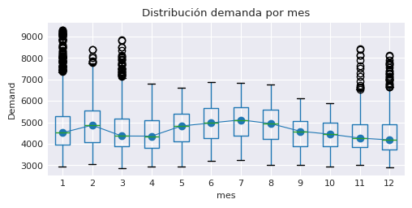

```python
# Distribución de la demanda por mes
# ==============================================================================
fig, ax = plt.subplots(figsize=(5.5, 2.5))
datos['mes'] = datos.index.month
datos.boxplot(column='Demand', by='mes', ax=ax,)
datos.groupby('mes')['Demand'].median().plot(style='o-', linewidth=0.8, ax=ax)
ax.set_ylabel('Demand')
ax.set_title('Distribución demanda por mes')
fig.suptitle('');
```

Se observa que hay una estacionalidad anual, con valores de demanda (mediana) superiores en los meses de Junio, Julio y Agosto, y con elevados picos de demanda en los meses de Noviembre, Diciembre, Enero, Febrero y Marzo.

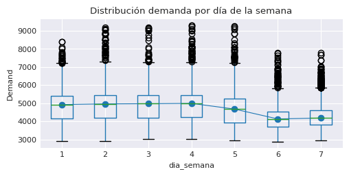

```python
# Distribución de la demanda por día de la semana
# ==============================================================================
fig, ax = plt.subplots(figsize=(5.5, 2.5))
datos['dia_semana'] = datos.index.day_of_week + 1
datos.boxplot(column='Demand', by='dia_semana', ax=ax)
datos.groupby('dia_semana')['Demand'].median().plot(style='o-', linewidth=0.8, ax=ax)
ax.set_ylabel('Demand')
ax.set_title('Distribución demanda por día de la semana')
fig.suptitle('');
```

Se aprecia una estacionalidad semanal, con valores de demanda inferiores durante el fin de semana.

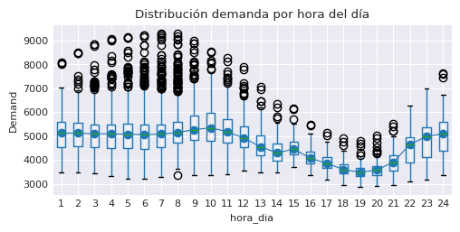

```python
# Distribución de la demanda por hora del día
# ==============================================================================
fig, ax = plt.subplots(figsize=(5.5, 2.5))
datos['hora_dia'] = datos.index.hour + 1
datos.boxplot(column='Demand', by='hora_dia', ax=ax)
datos.groupby('hora_dia')['Demand'].median().plot(style='o-', linewidth=0.8, ax=ax)
ax.set_ylabel('Demand')
ax.set_title('Distribución demanda por hora del día')
fig.suptitle('');
```

También existe una estacionalidad diaria, la demanda se reduce entre las 16 y las 21 horas.

### Gráficos de autocorrelación

Los gráficos de autocorrelación muestran la correlación entre una serie temporal y sus valores pasados. Son una herramienta útil para identificar el orden de un modelo autorregresivo, es decir, los valores pasados (lags) que se deben incluir en el modelo.

La función de autocorrelación (ACF) mide la correlación entre una serie temporal y sus valores pasados. La función de autocorrelación parcial (PACF) mide la correlación entre una serie temporal y sus valores pasados, pero solo después de eliminar las variaciones explicadas por los valores pasados intermedios.

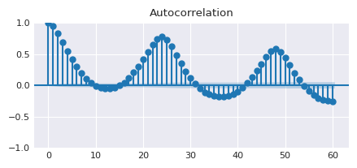

```python
# Gráfico autocorrelación
# ==============================================================================
fig, ax = plt.subplots(figsize=(5, 2))
plot_acf(datos.Demand, ax=ax, lags=60)
plt.show()
```

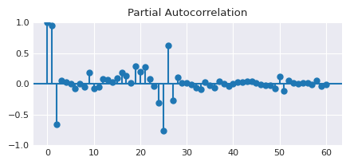

```python
# Gráfico autocorrelación parcial
# ==============================================================================
fig, ax = plt.subplots(figsize=(5, 2))
plot_pacf(datos.Demand, ax=ax, lags=60)
plt.show()
```

Los gráficos de autocorrelación y autocorrelación parcial muestran una clara asociación entre la demanda de una hora y las horas anteriores, así como entre la demanda de una hora y la demanda de esa misma hora los días anteriores. Este tipo de correlación, es un indicativo de que los modelos autorregresivos pueden funcionar bien.

## Baseline

Al enfrentarse a un problema de forecasting, es recomendable disponer de un modelo de referencia (*baseline*). Suele tratarse de un modelo muy sencillo que puede utilizarse como referencia para evaluar si merece la pena aplicar modelos más complejos.

Skforecast permite crear fácilmente un modelo de referencia con su clase [ForecasterEquivalentDate](https://skforecast.org/latest/user_guides/forecasting-baseline.html). Este modelo, también conocido como *Seasonal Naive Forecasting*, simplemente devuelve el valor observado en el mismo periodo de la temporada anterior (por ejemplo, el mismo día laboral de la semana anterior, la misma hora del día anterior, etc.).

A partir del análisis exploratorio realizado, el modelo de referencia será el que prediga cada hora utilizando el valor de la misma hora del día anterior.

**✎ Nota**

En las siguientes celdas de código, se entrena un modelo *baseline* y se evalúa su capacidad predictiva mediante un proceso de *backtesting*. Si este concepto es nuevo para ti, no te preocupes, se explicará en detalle a lo largo del documento. Por ahora, basta con saber que el proceso de *backtesting* consiste en entrenar el modelo con una cierta cantidad de datos y evaluar su capacidad predictiva con los datos que el modelo no ha visto. La métrica del error se utilizará como referencia para comparar la capacidad predictiva de los modelos más complejos que se implementarán a lo largo del documento.

```python
#Crear un baseline: valor de la misma hora del día anterior
# ==============================================================================
forecaster = ForecasterEquivalentDate(
                 offset    = pd.DateOffset(days=1),
                 n_offsets = 1
             )

# Entremaiento del forecaster
# ==============================================================================
forecaster.fit(y=datos.loc[:fin_validacion, 'Demand'])
forecaster
```

```
========================
ForecasterEquivalentDate
========================
Offset: <DateOffset: days=1>
Number of offsets: 1
Aggregation function: mean
Window size: 24
Training range: [Timestamp('2012-01-01 00:00:00'), Timestamp('2014-11-30 23:00:00')]
Training index type: DatetimeIndex
Training index frequency: H
Creation date: 2024-05-05 21:46:31
Last fit date: 2024-05-05 21:46:31
Skforecast version: 0.12.0
Python version: 3.11.8
Forecaster id: None
```

```python
# Backtesting
# ==============================================================================
metric, predictions = backtesting_forecaster(
                          forecaster         = forecaster,
                          y                  = datos['Demand'],
                          steps              = 24,
                          metric             = 'mean_absolute_error',
                          initial_train_size = len(datos.loc[:fin_validacion]),
                          refit              = False,
                          n_jobs             = 'auto',
                          verbose            = False,
                          show_progress      = True
                      )

print(f"Backtest error (MAE): {metric}")
```

```
Backtest error (MAE): 308.3752715958334
```

## Modelo autoregresivo recursivo

Se entrena un modelo autorregresivo recursivo (`ForecasterAutoreg`) con *gradient boosting* [LGBMRegressor](https://lightgbm.readthedocs.io/en/latest/pythonapi/lightgbm.LGBMRegressor.html) como regresor. Se utiliza una ventana temporal de 24 horas (24 lags) para predecir la demanda de la hora siguiente. Esto significa que los valores de demanda de las 24 horas anteriores se utilizan como predictores. Los hiperparámetros del regresor se dejan en sus valores por defecto.

```python
# Crear el forecaster
# ==============================================================================
forecaster = ForecasterAutoreg(
                 regressor = LGBMRegressor(random_state=15926, verbose=-1),
                 lags      = 24
             )

# Entrena el forecaster
# ==============================================================================
forecaster.fit(y=datos.loc[:fin_validacion, 'Demand'])
forecaster
```

```
=================
ForecasterAutoreg
=================
Regressor: LGBMRegressor(random_state=15926, verbose=-1)
Lags: [ 1  2  3  4  5  6  7  8  9 10 11 12 13 14 15 16 17 18 19 20 21 22 23 24]
Transformer for y: None
Transformer for exog: None
Window size: 24
Weight function included: False
Differentiation order: None
Exogenous included: False
Type of exogenous variable: None
Exogenous variables names: None
Training range: [Timestamp('2012-01-01 00:00:00'), Timestamp('2014-11-30 23:00:00')]
Training index type: DatetimeIndex
Training index frequency: H
Regressor parameters: {'boosting_type': 'gbdt', 'class_weight': None, 'colsample_bytree': 1.0, 'importance_type': 'split', 'learning_rate': 0.1, 'max_depth': -1, 'min_child_samples': 20, 'min_child_weight': 0.001, 'min_split_gain': 0.0, 'n_estimators': 100, 'n_jobs': None, 'num_leaves': 31, 'objecti…
fit_kwargs: {}
Creation date: 2024-05-05 21:46:32
Last fit date: 2024-05-05 21:46:32
Skforecast version: 0.12.0
Python version: 3.11.8
Forecaster id: None
```

### Backtesting

Para obtener una estimación robusta de la capacidad predictiva del modelo, se realiza un proceso de [*backtesting*](https://skforecast.org/latest/user_guides/backtesting.html). El proceso de *backtesting* consiste en generar una predicción para cada observación del conjunto de test, siguiendo el mismo procedimiento que se seguiría si el modelo estuviese en producción, y finalmente comparar el valor predicho con el valor real.

El proceso de backtesting se aplica mediante la función `backtesting_forecaster()`. Para este caso de uso, la simulación se lleva a cabo de la siguiente manera: el modelo se entrena con datos de 2012-01-01 00:00 a 2014-11-30 23:59, y luego predice las siguientes 24 horas cada día a las 23:59. La métrica de error utilizada es el error absoluto medio (MAE).

**✎ Nota**

A partir de la versión **skforecast 0.9.0**, todas las funciones de backtesting y búsqueda de hiperparámetros del módulo `model_selection` incluyen el parámetro `n_jobs` que permite su paralelización y, por tanto, mejora su rendimiento. Los beneficios de la paralelización dependen de varios factores, incluyendo el regresor seleccionado, el número de entrenamientos a realizar y el volumen de datos involucrados. Cuando el parámetro `n_jobs` se establece en `'auto'`, el nivel de paralelización se selecciona automáticamente basándose en reglas heurísticas que pretenden elegir la mejor configuración posible para cada escenario.

```python
# Backtesting
# ==============================================================================
metrica, predicciones = backtesting_forecaster(
                            forecaster         = forecaster,
                            y                  = datos['Demand'],
                            steps              = 24,
                            metric             = 'mean_absolute_error',
                            initial_train_size = len(datos.loc[:fin_validacion]),
                            refit              = False,
                            n_jobs             = 'auto',
                            verbose            = True,
                            show_progress      = True
                        )
```

```
Information of backtesting process
----------------------------------
Number of observations used for initial training: 25560
Number of observations used for backtesting: 720
    Number of folds: 30
    Number of steps per fold: 24
    Number of steps to exclude from the end of each train set before test (gap): 0

Fold: 0
    Training:   2012-01-01 00:00:00 -- 2014-11-30 23:00:00  (n=25560)
    Validation: 2014-12-01 00:00:00 -- 2014-12-01 23:00:00  (n=24)
Fold: 1
    Training:   2012-01-01 00:00:00 -- 2014-11-30 23:00:00  (n=25560)
    Validation: 2014-12-02 00:00:00 -- 2014-12-02 23:00:00  (n=24)
Fold: 2
    Training:   2012-01-01 00:00:00 -- 2014-11-30 23:00:00  (n=25560)
    Validation: 2014-12-03 00:00:00 -- 2014-12-03 23:00:00  (n=24)
Fold: 3
    Training:   2012-01-01 00:00:00 -- 2014-11-30 23:00:00  (n=25560)
    Validation: 2014-12-04 00:00:00 -- 2014-12-04 23:00:00  (n=24)
Fold: 4
    Training:   2012-01-01 00:00:00 -- 2014-11-30 23:00:00  (n=25560)
    Validation: 2014-12-05 00:00:00 -- 2014-12-05 23:00:00  (n=24)
Fold: 5
    Training:   2012-01-01 00:00:00 -- 2014-11-30 23:00:00  (n=25560)
    Validation: 2014-12-06 00:00:00 -- 2014-12-06 23:00:00  (n=24)
Fold: 6
    Training:   2012-01-01 00:00:00 -- 2014-11-30 23:00:00  (n=25560)
    Validation: 2014-12-07 00:00:00 -- 2014-12-07 23:00:00  (n=24)
Fold: 7
    Training:   2012-01-01 00:00:00 -- 2014-11-30 23:00:00  (n=25560)
    Validation: 2014-12-08 00:00:00 -- 2014-12-08 23:00:00  (n=24)
Fold: 8
    Training:   2012-01-01 00:00:00 -- 2014-11-30 23:00:00  (n=25560)
    Validation: 2014-12-09 00:00:00 -- 2014-12-09 23:00:00  (n=24)
Fold: 9
    Training:   2012-01-01 00:00:00 -- 2014-11-30 23:00:00  (n=25560)
    Validation: 2014-12-10 00:00:00 -- 2014-12-10 23:00:00  (n=24)
Fold: 10
    Training:   2012-01-01 00:00:00 -- 2014-11-30 23:00:00  (n=25560)
```

[output cut: 43 more lines]

```
Fold: 25
    Training:   2012-01-01 00:00:00 -- 2014-11-30 23:00:00  (n=25560)
    Validation: 2014-12-26 00:00:00 -- 2014-12-26 23:00:00  (n=24)
Fold: 26
    Training:   2012-01-01 00:00:00 -- 2014-11-30 23:00:00  (n=25560)
    Validation: 2014-12-27 00:00:00 -- 2014-12-27 23:00:00  (n=24)
Fold: 27
    Training:   2012-01-01 00:00:00 -- 2014-11-30 23:00:00  (n=25560)
    Validation: 2014-12-28 00:00:00 -- 2014-12-28 23:00:00  (n=24)
Fold: 28
    Training:   2012-01-01 00:00:00 -- 2014-11-30 23:00:00  (n=25560)
    Validation: 2014-12-29 00:00:00 -- 2014-12-29 23:00:00  (n=24)
Fold: 29
    Training:   2012-01-01 00:00:00 -- 2014-11-30 23:00:00  (n=25560)
    Validation: 2014-12-30 00:00:00 -- 2014-12-30 23:00:00  (n=24)
```

```python
# Gráfico prediccion vs valores reales
# ==============================================================================
fig = go.Figure()
trace1 = go.Scatter(x=datos_test.index, y=datos_test['Demand'], name="test", mode="lines")
trace2 = go.Scatter(x=predicciones.index, y=predicciones['pred'], name="prediction", mode="lines")
fig.add_trace(trace1)
fig.add_trace(trace2)
fig.update_layout(
    title="Real value vs predicted in test data",
    xaxis_title="Date time",
    yaxis_title="Demand",
    width=800,
    height=400,
    margin=dict(l=20, r=20, t=35, b=20),
    legend=dict(
        orientation="h",
        yanchor="top",
        y=1.1,
        xanchor="left",
        x=0.001
    )
)
fig.show()
```

[interactive chart not shown]

```python
# Error backtest
# ==============================================================================
print(f'Error de backtest (MAE): {metrica}')
```

```
Error de backtest (MAE): 236.38849515592196
```

El modelo autorregresivo alcanza un MAE inferior al del modelo *baseline*. Esto significa que el modelo autorregresivo es capaz de predecir la demanda de electricidad del día siguiente con mayor precisión que el modelo utilizado como referencia.

### Optimización de hiperparámetros (*tuning*)

El `ForecasterAutoreg` entrenado utiliza los primeros 24 lags y un modelo `LGMBRegressor` con los hiperparámetros por defecto. Sin embargo, no hay ninguna razón por la que estos valores sean los más adecuados. Para encontrar los mejores hiperparámetros, se realiza una [Búsqueda Bayesiana](https://skforecast.org/latest/user_guides/hyperparameter-tuning-and-lags-selection#bayesian-search) utilizando la función `bayesian_search_forecaster()`. La búsqueda se lleva a cabo utilizando el mismo proceso de *backtesting* que antes, pero cada vez, el modelo se entrena con diferentes combinaciones de hiperparámetros y lags. Es importante señalar que la búsqueda de hiperparámetros debe realizarse utilizando el conjunto de validación, nunca con los datos de test.

**✎ Nota**

Desde la versión `0.12.0` los lags se incluye dentro del espacio de búsqueda (`search_space`).

```python
# Búsqueda bayesiana de hiperparámetros
# ==============================================================================
forecaster = ForecasterAutoreg(
                 regressor = LGBMRegressor(random_state=15926, verbose=-1),
                 lags      = 24, # Este valor se modifica durante la búsqueda
             )

# Lags utilizados como predictores
lags_grid = [24, [1, 2, 3, 23, 24, 25, 47, 48, 49]]

# Espacio de búsqueda de hiperparámetros
def search_space(trial):
    search_space  = {
        'n_estimators'  : trial.suggest_int('n_estimators', 600, 1200, step=100),
        'max_depth'     : trial.suggest_int('max_depth', 3, 10, step=1),
        'learning_rate' : trial.suggest_float('learning_rate', 0.01, 0.5),
        'reg_alpha'     : trial.suggest_float('reg_alpha', 0, 1, step=0.1),
        'reg_lambda'    : trial.suggest_float('reg_lambda', 0, 1, step=0.1),
        'lags'          : trial.suggest_categorical('lags', lags_grid)
    }
    return search_space

resultados_busqueda, frozen_trial = bayesian_search_forecaster(
                                        forecaster         = forecaster,
                                        y                  = datos.loc[:fin_validacion, 'Demand'],
                                        steps              = 24,
                                        metric             = 'mean_absolute_error',
                                        search_space       = search_space,
                                        initial_train_size = len(datos[:fin_train]),
                                        refit              = False,
                                        n_trials           = 20, # Aumentar para una búsqueda más exhaustiva
                                        random_state       = 123,
                                        return_best        = True,
                                        n_jobs             = 'auto',
                                        verbose            = False,
                                        show_progress      = True
                                    )
```

```
`Forecaster` refitted using the best-found lags and parameters, and the whole data set:
  Lags: [ 1  2  3  4  5  6  7  8  9 10 11 12 13 14 15 16 17 18 19 20 21 22 23 24]
  Parameters: {'n_estimators': 800, 'max_depth': 8, 'learning_rate': 0.05513142057308684, 'reg_alpha': 0.4, 'reg_lambda': 0.4}
  Backtesting metric: 237.8559671096808
```

```python
# Resultados de la búsqueda
# ==============================================================================
resultados_busqueda.head(10)
```

|  | lags | params | mean_absolute_error | n_estimators | max_depth | learning_rate | reg_alpha | reg_lambda |
| --- | --- | --- | --- | --- | --- | --- | --- | --- |
| 4 | [1, 2, 3, 4, 5, 6, 7, 8, 9, 10, 11, 12, 13, 14... | {'n_estimators': 800, 'max_depth': 8, 'learnin... | 237.855967 | 800.0 | 8.0 | 0.055131 | 0.4 | 0.4 |
| 19 | [1, 2, 3, 4, 5, 6, 7, 8, 9, 10, 11, 12, 13, 14... | {'n_estimators': 700, 'max_depth': 9, 'learnin... | 238.297293 | 700.0 | 9.0 | 0.059282 | 0.5 | 0.1 |
| 17 | [1, 2, 3, 4, 5, 6, 7, 8, 9, 10, 11, 12, 13, 14... | {'n_estimators': 1100, 'max_depth': 9, 'learni... | 238.399788 | 1100.0 | 9.0 | 0.165919 | 0.5 | 0.7 |
| 1 | [1, 2, 3, 4, 5, 6, 7, 8, 9, 10, 11, 12, 13, 14... | {'n_estimators': 1000, 'max_depth': 6, 'learni... | 239.635156 | 1000.0 | 6.0 | 0.202138 | 0.3 | 0.8 |
| 16 | [1, 2, 3, 4, 5, 6, 7, 8, 9, 10, 11, 12, 13, 14... | {'n_estimators': 1200, 'max_depth': 5, 'learni... | 239.929035 | 1200.0 | 5.0 | 0.085786 | 0.3 | 0.3 |
| 11 | [1, 2, 3, 4, 5, 6, 7, 8, 9, 10, 11, 12, 13, 14... | {'n_estimators': 1200, 'max_depth': 4, 'learni... | 242.633076 | 1200.0 | 4.0 | 0.185077 | 0.3 | 1.0 |
| 14 | [1, 2, 3, 4, 5, 6, 7, 8, 9, 10, 11, 12, 13, 14... | {'n_estimators': 700, 'max_depth': 5, 'learnin... | 244.464263 | 700.0 | 5.0 | 0.145675 | 0.0 | 0.3 |
| 12 | [1, 2, 3, 4, 5, 6, 7, 8, 9, 10, 11, 12, 13, 14... | {'n_estimators': 600, 'max_depth': 7, 'learnin... | 248.248482 | 600.0 | 7.0 | 0.216223 | 0.1 | 1.0 |
| 15 | [1, 2, 3, 4, 5, 6, 7, 8, 9, 10, 11, 12, 13, 14... | {'n_estimators': 900, 'max_depth': 10, 'learni... | 248.687497 | 900.0 | 10.0 | 0.266508 | 0.4 | 0.8 |
| 10 | [1, 2, 3, 4, 5, 6, 7, 8, 9, 10, 11, 12, 13, 14... | {'n_estimators': 600, 'max_depth': 10, 'learni... | 250.548354 | 600.0 | 10.0 | 0.033252 | 0.4 | 0.0 |

Al indicar `return_best = True`, el objeto forecaster se actualiza automáticamente con la mejor configuración encontrada y se entrena con el conjunto de datos completo. Este modelo final puede utilizarse para obtener predicciones sobre nuevos datos.

```python
# Mejor modelo
# ==============================================================================
forecaster
```

```
=================
ForecasterAutoreg
=================
Regressor: LGBMRegressor(learning_rate=0.05513142057308684, max_depth=8, n_estimators=800,
              random_state=15926, reg_alpha=0.4, reg_lambda=0.4, verbose=-1)
Lags: [ 1  2  3  4  5  6  7  8  9 10 11 12 13 14 15 16 17 18 19 20 21 22 23 24]
Transformer for y: None
Transformer for exog: None
Window size: 24
Weight function included: False
Differentiation order: None
Exogenous included: False
Type of exogenous variable: None
Exogenous variables names: None
Training range: [Timestamp('2012-01-01 00:00:00'), Timestamp('2014-11-30 23:00:00')]
Training index type: DatetimeIndex
Training index frequency: H
Regressor parameters: {'boosting_type': 'gbdt', 'class_weight': None, 'colsample_bytree': 1.0, 'importance_type': 'split', 'learning_rate': 0.05513142057308684, 'max_depth': 8, 'min_child_samples': 20, 'min_child_weight': 0.001, 'min_split_gain': 0.0, 'n_estimators': 800, 'n_jobs': None, 'num_leaves…
fit_kwargs: {}
Creation date: 2024-05-05 21:46:33
Last fit date: 2024-05-05 21:49:00
Skforecast version: 0.12.0
Python version: 3.11.8
Forecaster id: None
```

### Backtesting con datos de test

Una vez identificada la mejor combinación de hiperparámetros utilizando los datos de validación, se evalúa la capacidad predictiva del modelo cuando se aplica al conjunto de test. Se recomienda revisar la documentación de la función [backtesting_forecaster()](https://joaquinamatrodrigo.github.io/skforecast/latest/user_guides/backtesting.html) para comprender mejor sus capacidades. Esto ayudará a utilizar todo su potencial para analizar la capacidad predictiva del modelo.

```python
# Backtest modelo final
# ==============================================================================
metrica, predicciones = backtesting_forecaster(
                            forecaster         = forecaster,
                            y                  = datos['Demand'],
                            steps              = 24,
                            metric             = 'mean_absolute_error',
                            initial_train_size = len(datos[:fin_validacion]),
                            refit              = False,
                            n_jobs             = 'auto',
                            verbose            = False,
                            show_progress      = True
                        )

print(f"Error de backtest (MAE): {metrica}")
predicciones.head()
```

```
Error de backtest (MAE): 198.26458584924902
```

|  | pred |
| --- | --- |
| 2014-12-01 00:00:00 | 5613.701110 |
| 2014-12-01 01:00:00 | 5597.650623 |
| 2014-12-01 02:00:00 | 5583.070192 |
| 2014-12-01 03:00:00 | 5607.766871 |
| 2014-12-01 04:00:00 | 5602.253078 |

Tras la optimización de lags e hiperparámetros, se ha conseguido reducir el error de predicción de forma notable.

## Forecasting con variables exógenas

Hasta ahora, sólo se han utilizado como predictores los valores pasados (lags) de la serie temporal. Sin embargo, es posible incluir otras variables como predictores. Estas variables se conocen como variables exógenas (*features*) y su uso puede mejorar la capacidad predictiva del modelo. Un punto muy importante que hay que tener en cuenta es que los valores de las variables exógenas deben conocerse en el momento de la predicción.

Ejemplos habituales de variables exógenas son aquellas obtenidas del calendario, como el día de la semana, el mes, el año o los días festivos. Las variables meteorológicas como la temperatura, la humedad y el viento también entran en esta categoría, al igual que las variables económicas como la inflación y los tipos de interés.

**⚠ Warning**

Las variables exógenas deben conocerse en el momento de la predicción. Por ejemplo, si se utiliza la temperatura como variable exógena, el valor de la temperatura para la hora siguiente debe conocerse en el momento de la previsión. Si no se conoce el valor de la temperatura, la predicción no será posible.  
Las variables meteorológicas deben utilizarse con precaución. Cuando el modelo se pone en producción, las condiciones meteorológicas futuras no se conocen, sino que son predicciones realizadas por los servicios meteorológicos. Al tratarse de predicciones, introducen errores en el modelo de previsión. Como consecuencia, es probable que las predicciones del modelo empeoren. Una forma de anticiparse a este problema, y conocer (no evitar) el rendimiento esperado del modelo, es utilizar las previsiones meteorológicas disponibles en el momento en que se entrena el modelo, en lugar de las condiciones reales registradas.

### Variables exógenas

A continuación, se crean variables exógenas basadas en información del calendario, las horas de salida y puesta del sol, la temperatura y los días festivos. Estas nuevas variables se añaden a los conjuntos de entrenamiento, validación y test, y se utilizan como predictores en el modelo autorregresivo.

```python
# Variables basadas en el calendario
# ==============================================================================
variables_calendario = pd.DataFrame(index=datos.index)
variables_calendario['mes'] = variables_calendario.index.month
variables_calendario['semana_anyo'] = variables_calendario.index.isocalendar().week
variables_calendario['dia_semana'] = variables_calendario.index.day_of_week + 1
variables_calendario['hora_dia'] = variables_calendario.index.hour + 1

# Variables basadas en la luz solar
# ==============================================================================
location = LocationInfo(
    "Melbourne",
    "Australia",
    latitude=-37.8,
    longitude=144.95,
    timezone='Australia/Melbourne'
)
hora_amanecer = [
    sun(location.observer, date=date, tzinfo=location.timezone)['sunrise'].hour
    for date in datos.index
]
hora_anochecer = [
    sun(location.observer, date=date, tzinfo=location.timezone)['sunset'].hour
    for date in datos.index
]
variables_solares = pd.DataFrame({
                         'hora_amanecer': hora_amanecer,
                         'hora_anochecer': hora_anochecer},
                         index = datos.index
                     )
variables_solares['horas_luz_solar'] = (
    variables_solares['hora_anochecer'] - variables_solares['hora_amanecer']
)
variables_solares['es_de_dia'] = np.where(
                                    (datos.index.hour >= variables_solares['hora_amanecer']) & \
                                    (datos.index.hour < variables_solares['hora_anochecer']),
                                    1,
                                    0
                                )

# Variables basadas en festivos
# ==============================================================================
variables_festivos = datos[['Holiday']].astype(int)
variables_festivos['holiday_dia_anterior'] = variables_festivos['Holiday'].shift(24)
variables_festivos['holiday_dia_siguiente'] = variables_festivos['Holiday'].shift(-24)

# Temperature features
# ==============================================================================
variables_temp = datos[['Temperature']].copy()
variables_temp['temp_roll_mean_1_dia'] = variables_temp['Temperature'].rolling(24, closed='left').mean()
variables_temp['temp_roll_mean_7_dia'] = variables_temp['Temperature'].rolling(24*7, closed='left').mean()
variables_temp['temp_roll_max_1_dia'] = variables_temp['Temperature'].rolling(24, closed='left').max()
variables_temp['temp_roll_min_1_dia'] = variables_temp['Temperature'].rolling(24, closed='left').min()
variables_temp['temp_roll_max_7_dia'] = variables_temp['Temperature'].rolling(24*7, closed='left').max()
variables_temp['temp_roll_min_7_dia'] = variables_temp['Temperature'].rolling(24*7, closed='left').min()


# Merge all exogenous variables
# ==============================================================================
variables_exogenas = pd.concat([
                         variables_calendario,
                         variables_solares,
                         variables_temp,
                         variables_festivos
                     ], axis=1)

variables_exogenas.head(4)
```

| Time | mes | semana_anyo | dia_semana | hora_dia | hora_amanecer | hora_anochecer | horas_luz_solar | es_de_dia | Temperature | temp_roll_mean_1_dia | temp_roll_mean_7_dia | temp_roll_max_1_dia | temp_roll_min_1_dia | temp_roll_max_7_dia | temp_roll_min_7_dia | Holiday | holiday_dia_anterior | holiday_dia_siguiente |
| --- | --- | --- | --- | --- | --- | --- | --- | --- | --- | --- | --- | --- | --- | --- | --- | --- | --- | --- |
| 2012-01-01 00:00:00 | 1 | 52 | 7 | 1 | 6 | 20 | 14 | 0 | 27.000 | NaN | NaN | NaN | NaN | NaN | NaN | 1 | NaN | 1.0 |
| 2012-01-01 01:00:00 | 1 | 52 | 7 | 2 | 6 | 20 | 14 | 0 | 29.650 | NaN | NaN | NaN | NaN | NaN | NaN | 1 | NaN | 1.0 |
| 2012-01-01 02:00:00 | 1 | 52 | 7 | 3 | 6 | 20 | 14 | 0 | 31.650 | NaN | NaN | NaN | NaN | NaN | NaN | 1 | NaN | 1.0 |
| 2012-01-01 03:00:00 | 1 | 52 | 7 | 4 | 6 | 20 | 14 | 0 | 32.675 | NaN | NaN | NaN | NaN | NaN | NaN | 1 | NaN | 1.0 |

Algunos aspectos del calendario, como las horas o los días, son cíclicos. Por ejemplo, la hora del día va de 0 a 23 horas. Aunque se interpreta como una variable continua, la hora 23:00 sólo dista una hora de las 00:00. Lo mismo ocurre con los meses del año, ya que diciembre sólo dista un mes de enero. El uso de funciones trigonométricas como seno y coseno permite representar patrones cíclicos y evitar incoherencias en la representación de los datos. Este enfoque se conoce como codificación cíclica y puede mejorar significativamente la capacidad predictiva de los modelos.

```python
# Codificación cíclica de las variables de calendario y luz solar
# ==============================================================================
def codificacion_ciclica(datos: pd.Series, longitud_ciclo: int) -> pd.DataFrame:
    """
    Codifica una variable cíclica con dos nuevas variables: seno y coseno.
    Se asume que el valor mínimo de la variable es 0. El valor máximo de la
    variable se pasa como argumento.

    Parameters
    ----------
    datos : pd.Series
        Serie con la variable a codificar.
    longitud_ciclo : int
        La longitud del ciclo. Por ejemplo, 12 para meses, 24 para horas, etc.
        Este valor se utiliza para calcular el ángulo del seno y coseno.

    Returns
    -------
    resultado : pd.DataFrame
        Dataframe con las dos nuevas características: seno y coseno.

    """

    seno = np.sin(2 * np.pi * datos/longitud_ciclo)
    coseno = np.cos(2 * np.pi * datos/longitud_ciclo)
    resultado =  pd.DataFrame({
                  f"{datos.name}_seno": seno,
                  f"{datos.name}_coseno": coseno
              })

    return resultado

mes_encoded = codificacion_ciclica(variables_exogenas['mes'], longitud_ciclo=12)
semana_anyo_encoded = codificacion_ciclica(variables_exogenas['semana_anyo'], longitud_ciclo=52)
dia_semana_encoded = codificacion_ciclica(variables_exogenas['dia_semana'], longitud_ciclo=7)
hora_dia_encoded = codificacion_ciclica(variables_exogenas['hora_dia'], longitud_ciclo=24)
hora_amanecer_encoded = codificacion_ciclica(variables_exogenas['hora_amanecer'], longitud_ciclo=24)
hora_anochecer_encoded = codificacion_ciclica(variables_exogenas['hora_anochecer'], longitud_ciclo=24)

variables_ciclicas = pd.concat([
                            mes_encoded,
                            semana_anyo_encoded,
                            dia_semana_encoded,
                            hora_dia_encoded,
                            hora_amanecer_encoded,
                            hora_anochecer_encoded
                        ], axis=1)
variables_exogenas = pd.concat([variables_exogenas, variables_ciclicas], axis=1)
variables_exogenas.head(3)
```

| Time | mes | semana_anyo | dia_semana | hora_dia | hora_amanecer | hora_anochecer | horas_luz_solar | es_de_dia | Temperature | temp_roll_mean_1_dia | ... | semana_anyo_seno | semana_anyo_coseno | dia_semana_seno | dia_semana_coseno | hora_dia_seno | hora_dia_coseno | hora_amanecer_seno | hora_amanecer_coseno | hora_anochecer_seno | hora_anochecer_coseno |
| --- | --- | --- | --- | --- | --- | --- | --- | --- | --- | --- | --- | --- | --- | --- | --- | --- | --- | --- | --- | --- | --- |
| 2012-01-01 00:00:00 | 1 | 52 | 7 | 1 | 6 | 20 | 14 | 0 | 27.00 | NaN | ... | 0.0 | 1.0 | -2.449294e-16 | 1.0 | 0.258819 | 0.965926 | 1.0 | 6.123234e-17 | -0.866025 | 0.5 |
| 2012-01-01 01:00:00 | 1 | 52 | 7 | 2 | 6 | 20 | 14 | 0 | 29.65 | NaN | ... | 0.0 | 1.0 | -2.449294e-16 | 1.0 | 0.500000 | 0.866025 | 1.0 | 6.123234e-17 | -0.866025 | 0.5 |
| 2012-01-01 02:00:00 | 1 | 52 | 7 | 3 | 6 | 20 | 14 | 0 | 31.65 | NaN | ... | 0.0 | 1.0 | -2.449294e-16 | 1.0 | 0.707107 | 0.707107 | 1.0 | 6.123234e-17 | -0.866025 | 0.5 |

3 rows × 30 columns

**✎ Nota**

Con fines ilustrativos, se han creado manualmente las variables del calendario y su codificación cíclica. Sin embargo, para un enfoque más eficiente y automatizado, se recomienda utiliar las clases [DatetimeFeatures](https://feature-engine.trainindata.com/en/latest/api_doc/datetime/DatetimeFeatures.html) y [CyclicalFeatures](https://feature-engine.trainindata.com/en/latest/user_guide/creation/CyclicalFeatures.html) disponibles en la librería *Feature-engine* y pasarlas directamente al argumento `transformer_exog` del forecaster.

En muchos casos, las variables exógenas no son independientes. Más bien, su efecto sobre la variable objetivo depende del valor de otras variables. Por ejemplo, el efecto de la temperatura en la demanda de electricidad depende de la hora del día. La interacción entre las variables exógenas puede captarse mediante nuevas variables que se obtienen multiplicando entre sí las variables existentes. Estas interacciones se obtienen fácilmente con la clase [PolynomialFeatures](https://scikit-learn.org/stable/modules/generated/sklearn.preprocessing.PolynomialFeatures.html) de scikit-learn.

```python
# Interacción entre variables exógenas
# ==============================================================================
transformer_poly = PolynomialFeatures(
                       degree           = 2,
                       interaction_only = True,
                       include_bias     = False
                   ).set_output(transform="pandas")
poly_cols = [
    'mes_seno',
    'mes_coseno',
    'semana_anyo_seno',
    'semana_anyo_coseno',
    'dia_semana_seno',
    'dia_semana_coseno',
    'hora_dia_seno',
    'hora_dia_coseno',
    'hora_amanecer_seno',
    'hora_amanecer_coseno',
    'hora_anochecer_seno',
    'hora_anochecer_coseno',
    'horas_luz_solar',
    'es_de_dia',
    'holiday_dia_anterior',
    'holiday_dia_siguiente',
    'temp_roll_mean_1_dia',
    'temp_roll_mean_7_dia',
    'temp_roll_max_1_dia',
    'temp_roll_min_1_dia',
    'temp_roll_max_7_dia',
    'temp_roll_min_7_dia',
    'Temperature',
    'Holiday'
]

variables_poly = transformer_poly.fit_transform(variables_exogenas[poly_cols].dropna())
variables_poly = variables_poly.drop(columns=poly_cols)
variables_poly.columns = [f"poly_{col}" for col in variables_poly.columns]
variables_poly.columns = variables_poly.columns.str.replace(" ", "__")
variables_exogenas = pd.concat([variables_exogenas, variables_poly], axis=1)
variables_exogenas.head(3)
```

| Time | mes | semana_anyo | dia_semana | hora_dia | hora_amanecer | hora_anochecer | horas_luz_solar | es_de_dia | Temperature | temp_roll_mean_1_dia | ... | poly_temp_roll_min_1_dia__temp_roll_max_7_dia | poly_temp_roll_min_1_dia__temp_roll_min_7_dia | poly_temp_roll_min_1_dia__Temperature | poly_temp_roll_min_1_dia__Holiday | poly_temp_roll_max_7_dia__temp_roll_min_7_dia | poly_temp_roll_max_7_dia__Temperature | poly_temp_roll_max_7_dia__Holiday | poly_temp_roll_min_7_dia__Temperature | poly_temp_roll_min_7_dia__Holiday | poly_Temperature__Holiday |
| --- | --- | --- | --- | --- | --- | --- | --- | --- | --- | --- | --- | --- | --- | --- | --- | --- | --- | --- | --- | --- | --- |
| 2012-01-01 00:00:00 | 1 | 52 | 7 | 1 | 6 | 20 | 14 | 0 | 27.00 | NaN | ... | NaN | NaN | NaN | NaN | NaN | NaN | NaN | NaN | NaN | NaN |
| 2012-01-01 01:00:00 | 1 | 52 | 7 | 2 | 6 | 20 | 14 | 0 | 29.65 | NaN | ... | NaN | NaN | NaN | NaN | NaN | NaN | NaN | NaN | NaN | NaN |
| 2012-01-01 02:00:00 | 1 | 52 | 7 | 3 | 6 | 20 | 14 | 0 | 31.65 | NaN | ... | NaN | NaN | NaN | NaN | NaN | NaN | NaN | NaN | NaN | NaN |

3 rows × 306 columns

```python
# Selección de variables exógenas incluidas en el modelo
# ==============================================================================
exog_features = []

# Columnas que terminan con _seno o _coseno son seleccionadas
exog_features.extend(variables_exogenas.filter(regex='_seno$|_coseno$').columns.tolist())

# Columnas que empiezan con temp_ son seleccionadas
exog_features.extend(variables_exogenas.filter(regex='^temp_.*').columns.tolist())

# Columnas que empiezan con holiday_ son seleccionadas
exog_features.extend(variables_exogenas.filter(regex='^holiday_.*').columns.tolist())

# Incluir temperatura y festivos
exog_features.extend(['Temperature', 'Holiday'])
```

```python
# Combinar variables exógenas seleccionadas con la serie temporal en un único DataFrame
# ==============================================================================
datos = datos[['Demand']].merge(
           variables_exogenas[exog_features],
           left_index=True,
           right_index=True,
           how='left'
       )
# Debido a la creación de medias móviles, existen valores ausentes al principio
# de la serie. Debido a holiday_dia_siguiente existen valores ausentes al final.
datos = datos.dropna()
datos = datos.astype('float32')

# Split data into train-val-test
datos_train = datos.loc[: fin_train, :].copy()
datos_val   = datos.loc[fin_train:fin_validacion, :].copy()
datos_test  = datos.loc[fin_validacion:, :].copy()
```

Los hiperparámetros y lags identificados como óptimos en la sección anterior se utilizan de nuevo para entrenar el modelo, pero esta vez, las variables exógenas también se incluyen como predictores.

```python
# Crear forecaster
# ==============================================================================
params = {
    'n_estimators': 800,
    'max_depth': 8,
    'learning_rate': 0.0551314,
    'reg_alpha': 0.4,
    'reg_lambda': 0.4,
    'random_state': 15926,
    'verbose': -1
}
forecaster = ForecasterAutoreg(
                 regressor = LGBMRegressor(**params),
                 lags      = 24
             )
```

```python
# Backtesting
# ==============================================================================
metrica, predicciones = backtesting_forecaster(
                            forecaster         = forecaster,
                            y                  = datos['Demand'],
                            exog               = datos[exog_features],
                            steps              = 24,
                            metric             = 'mean_absolute_error',
                            initial_train_size = len(datos[:fin_validacion]),
                            refit              = False,
                            n_jobs             = 'auto',
                            verbose            = False,
                            show_progress      = True
                       )

print(f"Error de backtest (MAE): {metrica:.2f}")
predicciones.head()
```

```
Error de backtest (MAE): 129.80
```

|  | pred |
| --- | --- |
| 2014-12-01 00:00:00 | 5561.629953 |
| 2014-12-01 01:00:00 | 5501.132966 |
| 2014-12-01 02:00:00 | 5453.086811 |
| 2014-12-01 03:00:00 | 5474.376494 |
| 2014-12-01 04:00:00 | 5530.322188 |

La inclusión de variables exógenas como predictores mejora aún más la capacidad predictiva del modelo.

## Forecasting probabilístico: Intervalos de predicción

Un intervalo de predicción define el intervalo dentro del cual es de esperar que se encuentre el verdadero valor de la variable respuesta con una determinada probabilidad. Rob J Hyndman y George Athanasopoulos, listan en su libro *Forecasting: Principles and Practice* [mútiples formas de estimar intervalos de predicción](https://otexts.com/fpp3/prediction-intervals.html), la mayoría los cuales requieren que los resudios (errores) del modelo se distribuyan de forma normal. Cuando no se puede asumir esta propiedad, se puede recurrir a *bootstrapping*, que solo asume que los residuos no están correlacionados. Este es uno de los métodos disponibles en skforecast. Se pude encontrar una explicación más detallada de los intervalos de predicción en [Probabilistic forecasting: prediction intervals and prediction distribution](https://joaquinamatrodrigo.github.io/skforecast/latest/user_guides/probabilistic-forecasting.html).

El siguiente código muestra cómo generar intervalos de predicción con un modelo autorregresivo. La función `prediction_interval()` se utiliza para estimar los intervalos para cada *step* predicho. Después, se utiliza la función `backtesting_forecaster()` para generar los intervalos de predicción de todo el conjunto de test. El argumento `interval` se utiliza para especificar la probabilidad de cobertura deseada de los intervalos. En este caso, `interval` se establece en `[10, 90]`, lo que significa que los intervalos se calculan con los percentiles 10 y 90, lo que da como resultado una cobertura teórica del 80%. El argumento `n_boot` se utiliza para especificar el número de iteraciones de *bootstraping* que se utilizan para estimar los intervalos. Cuanto mayor sea el número de muestras, más precisos serán los intervalos de predicción, pero más tiempo tardará el proceso.

```python
# Crear y entrenar el forecaster
# ==============================================================================
forecaster = ForecasterAutoreg(
                 regressor = LGBMRegressor(**params),
                 lags      = 24
             )

forecaster.fit(
    y    = datos.loc[:fin_train, 'Demand'],
    exog = datos.loc[:fin_train, exog_features]
)
```

```python
# Predecir intervalos
# ==============================================================================
# Dado que el modelo ha sido entrenado con variables exógenas, estas deben ser
# proporcionadas también en la predicción.
predicciones = forecaster.predict_interval(
                  exog     = datos.loc[fin_train:, exog_features],
                  steps    = 24,
                  interval = [10, 90],
              )
predicciones.head()
```

|  | pred | lower_bound | upper_bound |
| --- | --- | --- | --- |
| 2014-01-01 00:00:00 | 3632.907595 | 3597.005697 | 3666.728409 |
| 2014-01-01 01:00:00 | 3779.814713 | 3730.780320 | 3813.333882 |
| 2014-01-01 02:00:00 | 3864.840701 | 3816.042311 | 3913.918539 |
| 2014-01-01 03:00:00 | 3931.732495 | 3854.539271 | 3985.687516 |
| 2014-01-01 04:00:00 | 3981.538258 | 3910.052319 | 4043.020729 |

Por defecto, los intervalos se calculan utilizando los residuos *in-sample* (residuos del conjunto de entrenamiento). Sin embargo, esto puede dar lugar a intervalos demasiado estrechos (demasiado optimistas). Para evitarlo, se utiliza el método `set_out_sample_residuals()` para almacenar residuos *out-sample* calculados mediante *backtesting* con un conjunto de validación.

Si además de los residuos, se le pasan las correspondientes predicciones al método `set_out_sample_residuals()`, entonces los residuos utilizados en el proceso de *bootstrapping* se seleccionan condicionados al rango de valores de las predicciones. Esto puede ayudar a conseguir intervalos con mayor covertura a la vez que se mantienen lo más estrechos posibles.

```python
# Backtesting sobre los datos de validación para obtener los residuos out-sample
# ==============================================================================
_, predicciones_val = backtesting_forecaster(
                         forecaster         = forecaster,
                         y                  = datos.loc[:fin_validacion, 'Demand'], # Train + Validation
                         exog               = datos.loc[:fin_validacion, exog_features],
                         steps              = 24,
                         metric             = 'mean_absolute_error',
                         initial_train_size = len(datos.loc[:fin_train]),
                         refit              = False,
                         n_jobs             = 'auto',
                         verbose            = False,
                         show_progress      = True
                     )
residuos = datos.loc[predicciones_val.index, 'Demand'] - predicciones_val['pred']
residuos = residuos.dropna()
```

```
negative    4620
positive    3396
Name: count, dtype: int64
```

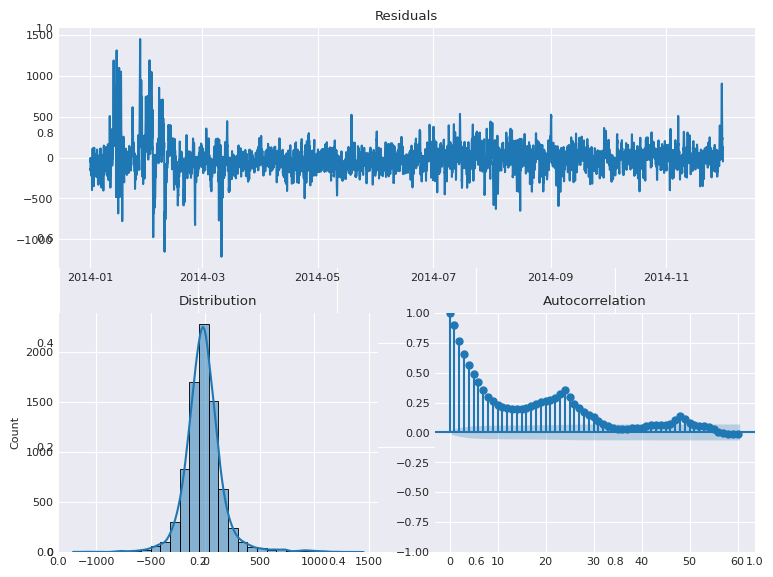

```python
# Distribución residuos Out-sample
# ==============================================================================
print(pd.Series(np.where(residuos < 0, 'negative', 'positive')).value_counts())
fig, ax = plt.subplots(figsize=(8, 6))
_ = plot_residuals(residuals=residuos, fig=fig)
fig.tight_layout()
```

```python
# Almacenar residuos out-sample en el forecaster
# ==============================================================================
forecaster.set_out_sample_residuals(
    residuals = residuos,
    y_pred    = datos.loc[predicciones_val.index, 'Demand']
)
```

A continuación, se repite el proceso de *backtesting* para generar los intervalos de predicción en el conjunto de test. Se indica el argumento `in_sample_residuals` en `False` para que se utilicen los residuos *out-sample* almacenados previamente.

```python
# Backtest con intervalos de predicción para el conjunto de test utilizando los
# residuos out-sample
# ==============================================================================
metrica, predicciones = backtesting_forecaster(
                            forecaster          = forecaster,
                            y                   = datos['Demand'],
                            exog                = datos[exog_features],
                            steps               = 24,
                            metric              = 'mean_absolute_error',
                            initial_train_size  = len(datos.loc[:fin_validacion]),
                            refit               = False,
                            interval            = [10, 90],
                            n_boot              = 250,
                            in_sample_residuals = False, # Se utilizan los residuos out-sample
                            binned_residuals    = True, # Residuos condicionados a los valores predichos
                            n_jobs              = 'auto',
                            verbose             = False,
                            show_progress       = True
                        )
predicciones.head(5)
```

|  | pred | lower_bound | upper_bound |
| --- | --- | --- | --- |
| 2014-12-01 00:00:00 | 5561.629953 | 5377.777405 | 5701.281989 |
| 2014-12-01 01:00:00 | 5501.132966 | 5190.982467 | 5788.547926 |
| 2014-12-01 02:00:00 | 5453.086811 | 5102.424659 | 5991.528615 |
| 2014-12-01 03:00:00 | 5474.376494 | 5037.869142 | 6262.746791 |
| 2014-12-01 04:00:00 | 5530.322188 | 5036.639154 | 6528.985275 |

```python
# Gráfico intervalos de predicción vs valores reales
# ==============================================================================
fig = go.Figure([
    go.Scatter(
        name='Predicción',
        x=predicciones.index,
        y=predicciones['pred'],
        mode='lines',
    ),
    go.Scatter(
        name='Valor real',
        x=datos_test.index,
        y=datos_test['Demand'],
        mode='lines',
    ),
    go.Scatter(
        name='Upper Bound',
        x=predicciones.index,
        y=predicciones['upper_bound'],
        mode='lines',
        marker=dict(color="#444"),
        line=dict(width=0),
        showlegend=False
    ),
    go.Scatter(
        name='Lower Bound',
        x=predicciones.index,
        y=predicciones['lower_bound'],
        marker=dict(color="#444"),
        line=dict(width=0),
        mode='lines',
        fillcolor='rgba(68, 68, 68, 0.3)',
        fill='tonexty',
        showlegend=False
    )
])
fig.update_layout(
    title="Predicción con intervalos de confianza vs valor real",
    xaxis_title="Fecha",
    yaxis_title="Demanda (MWh)",
    width=800,
    height=400,
    margin=dict(l=20, r=20, t=35, b=20),
    hovermode="x",
    legend=dict(
        orientation="h",
        yanchor="top",
        y=1.1,
        xanchor="left",
        x=0.001
    )
)
fig.show()
```

[interactive chart not shown]

```python
# Cobertura del intervalo predicho
# ==============================================================================
dentro_intervalo = np.where(
                       (datos.loc[fin_validacion:, 'Demand'] >= predicciones['lower_bound']) & \
                       (datos.loc[fin_validacion:, 'Demand'] <= predicciones['upper_bound']),
                       True,
                       False
                   )
cobertura = dentro_intervalo.mean()
area = (predicciones['upper_bound'] - predicciones['lower_bound']).sum()
print(f"Área total del intervalo: {round(area, 2)}")
print(f"Cobertura del intervalo predicho: {round(100*cobertura, 2)} %")
```

```
Área total del intervalo: 551718.67
Cobertura del intervalo predicho: 80.03 %
```

Utilizando los residuos *out-sample* (condicionados al valor de la predicción), la cobertura empírica observada es muy próxima a la cobertura teórica esperada.

**✎ Nota**

Para información detallada de las funcionalidades de forecasting probabilístico ofrecidas por skforecast visitar: [Probabilistic forecasting: prediction intervals and prediction distribution](https://skforecast.org/latest/user_guides/probabilistic-forecasting).

## Explicabilidad del modelo

Debido a la naturaleza compleja de muchos de los actuales modelos de machine learning, a menudo funcionan como cajas negras, lo que dificulta entender por qué han hecho una predicción u otra. Las técnicas de explicabilidad pretenden desmitificar estos modelos, proporcionando información sobre su funcionamiento interno y ayudando a generar confianza, mejorar la transparencia y cumplir los requisitos normativos en diversos ámbitos. Mejorar la explicabilidad de los modelos no sólo ayuda a comprender su comportamiento, sino también a identificar sesgos, mejorar su rendimiento y permitir a las partes interesadas tomar decisiones más informadas basadas en los conocimientos del machine learning

Skforecast es compatible con algunos de los métodos de explicabilidad más populares: [model-specific feature importances, SHAP values, and partial dependence plots](https://skforecast.org/latest/user_guides/explainability).

```python
# Crear y entrenar el forecaster
# ==============================================================================
forecaster = ForecasterAutoreg(
                 regressor = LGBMRegressor(**params),
                 lags      = 24
             )

forecaster.fit(
    y    = datos.loc[:fin_validacion, 'Demand'],
    exog = datos.loc[:fin_validacion, exog_features]
)
```

### Explicabilidad propia del modelo

La explicabilidad propia del modelo se refiere a la capacidad inherente de un modelo para ser interpretado y comprendido sin la necesidad de técnicas adicionales.

```python
# Importancia de los predictores en el modelo
# ==============================================================================
feature_importances = forecaster.get_feature_importances()
feature_importances.sort_values(by='importance', ascending=False).head(10)
```

|  | feature | importance |
| --- | --- | --- |
| 0 | lag_1 | 2052 |
| 110 | Temperature | 1046 |
| 23 | lag_24 | 912 |
| 1 | lag_2 | 882 |
| 87 | poly_hora_dia_seno__hora_dia_coseno | 618 |
| 22 | lag_23 | 605 |
| 2 | lag_3 | 576 |
| 105 | temp_roll_min_1_dia | 528 |
| 102 | temp_roll_mean_1_dia | 461 |
| 104 | temp_roll_max_1_dia | 449 |

**⚠ Warning**

El método `get_feature_importances()` sólo devuelve valores si el regresor del forecaster tiene el atributo `coef_` o `feature_importances_`, que son los estándares en scikit-learn.

### Shap values

Los valores SHAP (*SHapley Additive exPlanations*) son un método muy utilizado para explicar los modelos de machine learning, ya que ayudan a comprender cómo influyen las variables y los valores en las predicciones de forma visual y cuantitativa.

Se puede obtener un análisis SHAP a partir de modelos skforecast con sólo dos elementos:

- El regresor interno del forecaster.
- Las matrices de entrenamiento creadas a partir de la serie temporal y variables exógenas, utilizadas para ajustar el pronosticador.

Aprovechando estos dos componentes, los usuarios pueden crear explicaciones interpretables para sus modelos de skforecast. Estas explicaciones pueden utilizarse para verificar la fiabilidad del modelo, identificar los factores más significativos que contribuyen a las predicciones y comprender mejor la relación subyacente entre las variables de entrada y la variable objetivo.

```python
# Matrices de entrenamiento utilizadas por el forecaster para ajustar el regresor interno
# ==============================================================================
X_train, y_train = forecaster.create_train_X_y(
                       y    = datos_train['Demand'],
                       exog = datos_train[exog_features]
                   )
display(X_train.head(3))
display(y_train.head(3))
```

| Time | lag_1 | lag_2 | lag_3 | lag_4 | lag_5 | lag_6 | lag_7 | lag_8 | lag_9 | lag_10 | ... | temp_roll_mean_1_dia | temp_roll_mean_7_dia | temp_roll_max_1_dia | temp_roll_min_1_dia | temp_roll_max_7_dia | temp_roll_min_7_dia | holiday_dia_anterior | holiday_dia_siguiente | Temperature | Holiday |
| --- | --- | --- | --- | --- | --- | --- | --- | --- | --- | --- | --- | --- | --- | --- | --- | --- | --- | --- | --- | --- | --- |
| 2012-01-09 00:00:00 | 4886.074219 | 4664.689453 | 4390.567871 | 3873.921631 | 3498.672607 | 3348.528809 | 3458.686523 | 3739.490967 | 3630.717285 | 3897.311035 | ... | 20.281250 | 22.389137 | 27.075001 | 14.8 | 39.525002 | 14.35 | 0.0 | 0.0 | 19.200001 | 0.0 |
| 2012-01-09 01:00:00 | 4958.630371 | 4886.074219 | 4664.689453 | 4390.567871 | 3873.921631 | 3498.672607 | 3348.528809 | 3458.686523 | 3739.490967 | 3630.717285 | ... | 20.223959 | 22.308035 | 27.075001 | 14.8 | 39.525002 | 14.35 | 0.0 | 0.0 | 20.525000 | 0.0 |
| 2012-01-09 02:00:00 | 5039.643066 | 4958.630371 | 4886.074219 | 4664.689453 | 4390.567871 | 3873.921631 | 3498.672607 | 3348.528809 | 3458.686523 | 3739.490967 | ... | 20.141666 | 22.224852 | 27.075001 | 14.8 | 39.525002 | 14.35 | 0.0 | 0.0 | 21.100000 | 0.0 |

3 rows × 112 columns

```
Time
2012-01-09 00:00:00    4958.630371
2012-01-09 01:00:00    5039.643066
2012-01-09 02:00:00    5090.203125
Freq: H, Name: y, dtype: float32
```

```python
# Crear SHAP explainer (para modelos basados en árboles)
# ==============================================================================
explainer = shap.TreeExplainer(forecaster.regressor)

# Se selecciona una muestra del 50% de los datos para acelerar el cálculo
rng = np.random.default_rng(seed=785412)
sample = rng.choice(X_train.index, size=int(len(X_train)*0.5), replace=False)
X_train_sample = X_train.loc[sample, :]
shap_values = explainer.shap_values(X_train_sample)
```

**✎ Note**

La librería Shap cuenta con varios *Explainers*, cada uno diseñado para un tipo de modelo diferente. El `shap.TreeExplainer` explainer se utiliza para modelos basados en árboles, como el `LGBMRegressor` utilizado en este ejemplo. Para más información, consultar la [documentación de SHAP](https://shap.readthedocs.io/en/latest/tabular_examples.html).

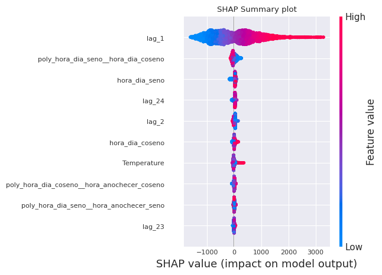

```python
# Shap summary plot (top 10)
# ==============================================================================
shap.summary_plot(shap_values, X_train_sample, max_display=10, show=False)
fig, ax = plt.gcf(), plt.gca()
ax.set_title("SHAP Summary plot")
ax.tick_params(labelsize=8)
fig.set_size_inches(8, 4.5)
```

```python
# Force plot para la primera observación de la muestra
# ==============================================================================
shap.force_plot(explainer.expected_value, shap_values[0,:], X_train_sample.iloc[0,:])
```

[output not shown]

## Selección de predictores

La selección de predictores (*feature selection*) es el proceso de identificar un subconjunto de predictores relevantes para su uso en la creación del modelo. Es un paso importante en el proceso de machine learning, ya que puede ayudar a reducir el sobreajuste, mejorar la precisión del modelo y reducir el tiempo de entrenamiento. Dado que los regresores subyacentes de skforecast siguen la API de scikit-learn, es posible utilizar los [métodos de selección de predictores](https://scikit-learn.org/stable/modules/feature_selection.html#feature-selection) disponibles en scikit-learn de forma sencilla con la función `select_features()`. Dos de los métodos más populares son [Recursive Feature Elimination](https://scikit-learn.org/stable/modules/feature_selection.html#recursive-feature-elimination) y [Sequential Feature Selection](https://scikit-learn.org/stable/modules/feature_selection.html#sequential-feature-selection).

**💡 Tip**

La selección de predictores es una herramienta potente para mejorar el rendimiento de los modelos de machine learning. Sin embargo, es computacionalmente costosa y puede requerir mucho tiempo. Dado que el objetivo es encontrar el mejor subconjunto de predictores, no el mejor modelo, no es necesario utilizar todos los datos disponibles ni un modelo muy complejo. En su lugar, se recomienda utilizar un pequeño subconjunto de los datos y un modelo sencillo. Una vez identificados los mejores predictores, el modelo puede entrenarse utilizando todo el conjunto de datos y una configuración más compleja. Por ejemplo, en este caso de uso, el mejor modelo es un `LGMBRegressor` con 800 árboles y una profundidad máxima de 8. Sin embargo, para la selección predictores, sólo se utilizan 100 árboles y una profundidad máxima de 5.

```python
# Crear forecaster
# ==============================================================================
regressor = LGBMRegressor(
                n_estimators = 100,
                max_depth = 5,
                random_state = 15926,
                verbose = -1
            )

forecaster = ForecasterAutoreg(
                 regressor = regressor,
                 lags = 24
             )

# Eliminación recursiva de predictores con validación cruzada
# ==============================================================================
selector = RFECV(
    estimator              = regressor,
    step                   = 1,
    cv                     = 3,
    min_features_to_select = 25,
    n_jobs                 = -1
)
lags_seleccionados, exog_seleccionadas = select_features(
    forecaster      = forecaster,
    selector        = selector,
    y               = datos_train['Demand'],
    exog            = datos_train[exog_features],
    select_only     = None,
    force_inclusion = None,
    subsample       = 0.5,
    random_state    = 123,
    verbose         = True,
)
```

```
Recursive feature elimination (RFECV)
-------------------------------------
Total number of records available: 17352
Total number of records used for feature selection: 8676
Number of features available: 112
    Autoreg (n=24)
    Exog    (n=88)
Number of features selected: 67
    Autoreg (n=24) : [1, 2, 3, 4, 5, 6, 7, 8, 9, 10, 11, 12, 13, 14, 15, 16, 17, 18, 19, 20, 21, 22, 23, 24]
    Exog    (n=43) : ['semana_anyo_seno', 'semana_anyo_coseno', 'dia_semana_seno', 'hora_dia_seno', 'hora_dia_coseno', 'poly_mes_seno__semana_anyo_seno', 'poly_mes_seno__semana_anyo_coseno', 'poly_mes_seno__dia_semana_coseno', 'poly_mes_seno__hora_dia_seno', 'poly_mes_seno__hora_dia_coseno', 'poly_m…
```

El `RFECV` de scikit-learn empieza entrenando un modelo con todos los predictores disponibles y calculando la importancia de cada uno en base a los atributos como `coef_` o `feature_importances_`. A continuación, se elimina el predictor menos importante y se realiza una validación cruzada para calcular el rendimiento del modelo con los predictores restantes. Este proceso se repite hasta que la eliminación de predictores adicionales no mejora la metrica de rendimiento elegida o se alcanza el `min_features_to_select`. El resultado final es un subconjunto de predictores que idealmente equilibra la simplicidad del modelo y su capacidad predictiva, determinada por el proceso de validación cruzada.

El forecater se entrena y reevalúa utilizando solo el conjunto de predictores seleccionados.

```python
# Crear forecaster
# ==============================================================================
forecaster = ForecasterAutoreg(
                 regressor = LGBMRegressor(**params),
                 lags      = lags_seleccionados,
             )

# Backtesting con los predictores seleccionados y los datos de test
# ==============================================================================
metrica, predicciones = backtesting_forecaster(
                            forecaster         = forecaster,
                            y                  = datos['Demand'],
                            exog               = datos[exog_seleccionadas],
                            steps              = 24,
                            metric             = 'mean_absolute_error',
                            initial_train_size = len(datos[:fin_validacion]),
                            refit              = False,
                            n_jobs             = 'auto',
                            verbose            = False,
                            show_progress      = True
                        )
print(f"Error de backtest (MAE): {metrica:.2f}")
```

```
Error de backtest (MAE): 129.00
```

El rendimiento del modelo no se ve comprometido. El número de características se reduce de 112 a 67, lo que simplifica y acelera el entrenamiento del modelo. Además, se reduce el riesgo de sobreajuste porque es menos probable que el modelo aprenda ruido de características irrelevantes.

## Forecaster direct multi-step

Los modelos `ForecasterAutoreg` y `ForecasterAutoregCustom` siguen una [estrategia recursiva](https://skforecast.org/latest/introduction-forecasting/introduction-forecasting.html#recursive-multi-step-forecasting) en la que cada nueva predicción se basa en las anteriores. Otra estrategia para predecir múltiples valores futuros consiste en entrenar un modelo diferente para cada paso (*step*) a predecir. Esto se conoce como [direct multi-step forecasting](https://skforecast.org/latest/introduction-forecasting/introduction-forecasting.html#direct-multi-step-forecasting) y, aunque es más costosa computacionalmente que la estrategia recursiva debido a la necesidad de entrenar múltiples modelos, puede dar mejores resultados.

```python
# Forecaster con le método direct
# ==============================================================================
forecaster = ForecasterAutoregDirect(
                 regressor        = LGBMRegressor(**params),
                 steps            = 24, # horizonte de predicción
                 lags             = lags_seleccionados
             )

# Backtesting
# ==============================================================================
metrica, predicciones = backtesting_forecaster(
                          forecaster         = forecaster,
                          y                  = datos['Demand'],
                          exog               = datos[exog_seleccionadas],
                          steps              = 24,
                          metric             = 'mean_absolute_error',
                          initial_train_size = len(datos[:fin_validacion]),
                          refit              = False,
                          n_jobs             = 'auto',
                          verbose            = False,
                          show_progress      = True
                      )
print(f"Error de backtest (MAE): {metrica:.2f}")
```

```
Error de backtest (MAE): 120.66
```

El modelo *direct multi-step* supera la capacidad de predicción del modelo recursivo, reduciendo aún más el error medio absoluto. Sin embargo, es importante tener en cuenta su mayor coste computacional a la hora de evaluar si merece la pena aplicarlo.

## Predicción diaria anticipada

En el apartado anterior, se evaluó el modelo asumiendo que las predicciones del día siguiente se ejecutan justo al final del día anterior. En la práctica, esto no resulta muy útil ya que, para las primeras horas del día, apenas se dispone de anticipación.

Supóngase ahora que, para poder tener suficiente margen de acción, a las 11:00 horas de cada día se tienen que generar las predicciones del día siguiente. Es decir, a las 11:00 del dia $D$ se tienen que predecir las horas [12, 13, 14, 15, 16, 17, 18, 19, 20, 21, 22, 23] de ese mismo día, y las horas [0, 1, 2, 3, 4, 5, 6, 7, 8, 9, 10, 11, 12, 13, 14, 15, 16, 17, 18, 19, 20, 21, 22, 23] del día $D+1$. Esto implica que se tienen que predecir un total de 36 horas a futuro aunque solo se almacenen las 24 últimas.

Este tipo de evaluación puede realizarse mediante la función `backtesting_forecaster()` y su parámetro `gap`. Además, el parámetro `allow_incomplete_fold` permite excluir la última iteración del análisis si no tiene el mismo tamaño que el número de *steps* requeridos. El proceso adaptado a este escenario se ejecuta diariamente y consta de los siguientes pasos:

1. A las 11:00h del primer día del conjunto de test, se predicen las 36 horas siguientes (las 12 horas que quedan del día más las 24 horas del día siguiente).
2. Se almacenan solo las predicciones del día siguiente, es decir, las 24 últimas.
3. Se añaden los datos de test hasta las 11:00 del día siguiente.
4. Se repite el proceso.

De esta forma, a las 11:00 de cada día, el modelo tiene acceso a los valores reales de demanda registrados hasta ese momento.

[figure not shown]

**⚠ Warning**

Se deben tener en cuenta las siguientes consideraciones:

- Los datos de entrenamiento deben terminar donde empieza el *gap*. En este caso, el `initial_train_size` debe ampliarse en 12 posiciones para que el primer punto a predecir sea el *2014-12-01 12:00:00*.
- En este ejemplo, aunque sólo se almacenan las últimas 24 predicciones (*steps*) para la evaluación del modelo, el número total de pasos predichos en cada iteración es de 36 (*steps* + *gap*).

```python
# Final de initial_train_size + 12 posiciones
# ==============================================================================
datos.iloc[:len(datos.loc[:fin_validacion])+12].tail(2)
```

| Time | Demand | mes_seno | mes_coseno | semana_anyo_seno | semana_anyo_coseno | dia_semana_seno | dia_semana_coseno | hora_dia_seno | hora_dia_coseno | hora_amanecer_seno | ... | temp_roll_mean_1_dia | temp_roll_mean_7_dia | temp_roll_max_1_dia | temp_roll_min_1_dia | temp_roll_max_7_dia | temp_roll_min_7_dia | holiday_dia_anterior | holiday_dia_siguiente | Temperature | Holiday |
| --- | --- | --- | --- | --- | --- | --- | --- | --- | --- | --- | --- | --- | --- | --- | --- | --- | --- | --- | --- | --- | --- |
| 2014-12-01 10:00:00 | 5084.011230 | -2.449294e-16 | 1.0 | -0.354605 | 0.935016 | 0.781832 | 0.62349 | 2.588190e-01 | -0.965926 | 0.965926 | ... | 25.589582 | 18.573214 | 30.950001 | 20.0 | 33.849998 | 11.15 | 0.0 | 0.0 | 19.90 | 0.0 |
| 2014-12-01 11:00:00 | 4851.066895 | -2.449294e-16 | 1.0 | -0.354605 | 0.935016 | 0.781832 | 0.62349 | 1.224647e-16 | -1.000000 | 0.965926 | ... | 25.129168 | 18.601191 | 29.500000 | 19.9 | 33.849998 | 11.15 | 0.0 | 0.0 | 19.35 | 0.0 |

2 rows × 89 columns

```python
# Forecaster
# ==============================================================================
forecaster = ForecasterAutoreg(
                 regressor = LGBMRegressor(**params),
                 lags      = lags_seleccionados,
             )

# Backtesting con gap
# ==============================================================================
metrica, predicciones = backtesting_forecaster(
                            forecaster            = forecaster,
                            y                     = datos['Demand'],
                            steps                 = 24,
                            metric                = 'mean_absolute_error',
                            initial_train_size    = len(datos.loc[:fin_validacion])+12,
                            gap                   = 12,
                            allow_incomplete_fold = True,
                            refit                 = False,
                            n_jobs                = 'auto',
                            verbose               = False,
                            show_progress         = True
                        )
print(f"Error de backtest (MAE): {metrica:.2f}")
```

```
Error de backtest (MAE): 337.71
```

Como era de esperar, el error aumenta a medida que el horizonte de previsión pasa de 24 a 36 horas.

## Conclusiones

El uso de modelos de gradient boosting ha demostrado ser una potente herramienta para predecir la demanda de energía. Una de las principales ventajas de estos modelos es que pueden incorporar fácilmente variables exógenas, lo que puede mejorar significativamente el poder predictivo del modelo. Además, el uso de técnicas de explicabilidad puede ayudar a comprender visual y cuantitativamente cómo afectan las variables y los valores a las predicciones. Todas estas cuestiones se abordan fácilmente con la biblioteca skforecast.

| Forecaster | Exogenous Variables | MAE backtest |
| --- | --- | --- |
| `ForecasterEquivalentDate` (Baseline) | False | 308.4 |
| `ForecasterAutoreg` | False | 198.3 |
| `ForecasterAutoreg` | True | 129.8 |
| `ForecasterAutoreg` | True (Feature Selection) | 129.0 |
| `ForecasterAutoregDirect` | True (Feature Selection) | 120.7 |

## Información de sesión

```python
import session_info
session_info.show(html=False)
```

```
-----
astral              3.2
lightgbm            4.3.0
matplotlib          3.8.4
numpy               1.26.4
optuna              3.4.0
pandas              2.1.4
plotly              5.21.0
session_info        1.0.0
shap                0.45.0
skforecast          0.12.0
sklearn             1.3.2
statsmodels         0.14.1
-----
IPython             8.22.2
jupyter_client      8.6.1
jupyter_core        5.7.2
-----
Python 3.11.8 (main, Feb 26 2024, 21:39:34) [GCC 11.2.0]
Linux-5.15.0-1058-aws-x86_64-with-glibc2.31
-----
Session information updated at 2024-04-29 10:12
```

## Bibliografía

Hyndman, R.J., & Athanasopoulos, G. (2021) Forecasting: principles and practice, 3rd edition, OTexts: Melbourne, Australia.

Time Series Analysis and Forecasting with ADAM Ivan Svetunkov

Joseph, M. (2022). Modern time series forecasting with Python: Explore industry-ready time series forecasting using modern machine learning and Deep Learning. Packt Publishing.

## Instrucciones para citar

**Cómo citar este documento**

Si utiliza este documento o parte de él, por favor, cite la fuente, ¡gracias!

Predicción (*forecasting*) de la demanda energética con machine learning por Joaquín Amat Rodrigo y Javier Escobar Ortiz, disponible con licencia Attribution-NonCommercial-ShareAlike 4.0 International (CC BY-NC-SA 4.0 DEED) at https://www.cienciadedatos.net/documentos/py29-forecasting-demanda-energia-electrica-python.html

**Cómo citar skforecast**

Si utiliza skforecast, le agradecemos que cite el software publicado.

Zenodo:

Amat Rodrigo, Joaquin, & Escobar Ortiz, Javier. (2023). skforecast (v0.10.0). Zenodo. https://doi.org/10.5281/zenodo.8382788

APA:

Amat Rodrigo, J., & Escobar Ortiz, J. (2023). skforecast (Version 0.10.0) [Computer software]. https://doi.org/10.5281/zenodo.8382788

BibTeX:

@software{skforecast, author = {Amat Rodrigo, Joaquin and Escobar Ortiz, Javier}, title = {skforecast}, version = {0.10.0}, month = {9}, year = {2023}, license = {BSD-3-Clause}, url = {https://skforecast.org/}, doi = {10.5281/zenodo.8382788} }

**¿Te ha gustado el artículo? Tu ayuda es importante**

Mantener un sitio web tiene unos costes elevados, tu contribución me ayudará a seguir generando contenido divulgativo gratuito. ¡Muchísimas gracias! 😊

Este documento creado por Joaquín Amat Rodrigo y Javier Escobar Ortiz tiene licencia [Attribution-NonCommercial-ShareAlike 4.0 International](https://creativecommons.org/licenses/by-nc-sa/4.0/).